# R Notebook

```r
library(dplyr)
library(lubridate)
library(tidyverse)
library(tsibble)
library(tsibbledata)
library(feasts)

date1 <- ymd_hms("2017-04-22 22:01:18")
date2 <- ymd_hms("2001-11-07 10:09:56")
```

```r
library(nycflights13)
```

**Question 1**

Extract the different components (year, month, mday, yday, wday) from the variable `date1`. Add the labels to the month and do not abbreviate the month labels.

```r
as_datetime(date1)
year(date1)
month(date1, label = TRUE, abbr =FALSE)
mday(date1)
yday(date1)
wday(date1)
```

**Question 2**

Add 14 days to your `date1` variable and store it in a variable called `next_fortnight`. Take away 10 years from your `date2` variable, and store it in `previous_decade`.

```r
next_fortnight <- date1 + days(14)
next_fortnight
```

```r
previous_decade <- date2 - years(10)
previous_decade
```

**Question 3**

Create a variable called `this_year` which contains today’s date. Then create an interval object which uses `this_year` and the `previous_decade` variable you made above. Store it in `interval_years`. *Hint: you’ll need to use lubridate::interval in order to get the right function, as tsibble has one too*

```r
this_year <- today()
this_year

interval_years <- lubridate::interval(this_year, previous_decade)
interval_years
```

**Question 4**

Change the time zone of both your date variables to “America/New_York”, and call them `nyc_date1` and `nyc_date2`.

```r
nyc_date1 <- with_tz(date1, tzone = "America/New_York")

nyc_date1


nyc_date2 <- with_tz(date2, tzone = "America/New_York")

nyc_date2
```

**Question 5**

Use the `flights` data from the `nycflights13` dataset. Make a date-time column called `departure_date` from the `year, month, day, hour, and minute` variables in the `flights` tibble.

```r
nycflights13::flights
```

```r
nycflights13::flights %>%
  mutate(departure_date = make_datetime(year, month, day, hour, minute))
```

# Time series familiarity

**Question 6**

Start with the `weather` data from the `nycflights13` package. Select all the variables related to temperature, humidity, and precipitation, and pick out the key and index variables. Have a look at your data, and write a small description of the time series you observe.

Here we can see that our data is collected in hourly format, with observations occuring every day.

```r
library(tsibbledata)
data(package = "tsibbledata")
```

```r
library(tsibble)
```

```r
nycflights13::weather
```

```r
nyc_weather <- nycflights13::weather %>%
select(origin, temp, humid, precip, time_hour)
nyc_weather
```

```r
class(nyc_weather)
#tsibble(nyc_weather)
```

key-? origin, after I read below. index- time component of data: time_hour

**Question 7**

Change the weather data into a tsibble. Hint, look up in the notes where we suggest using `as_tsibble` function. You’ll need to define an `index` and `key`.

```r
weather_tsibble <- nyc_weather %>%
  as_tsibble( key = origin, index = time_hour)
weather_tsibble
```

[output not shown]

[output cut: 990 more lines]

In order to create a time series tibble, remember you need to provide an *index* and a *key*. In our case, `time_hour` is the only column involving a date/date-time, and so this would be our index. A `tsibble` also requires a key, which defines individual observations that are tracked over time. In this example, the `origin` variable is the identifier, and therefore is our key. It is important to note that the duo of the index and key uniquely identifies each observation in a valid `tsibble`.

**Question 8**

Add a year and month column to your new tsibble weather data,

```r
weather_tsibble <- weather_tsibble %>%
    mutate(year = year(time_hour), month = month(time_hour))

nyc_weather
```

and create a basic line plot which shows the temperature data from each airport over time.

```r
nyc_weather  %>%
  select(origin, month, temp) %>%
  group_by(origin, month)  %>%
  summarise(mean_temp = mean(temp))
```

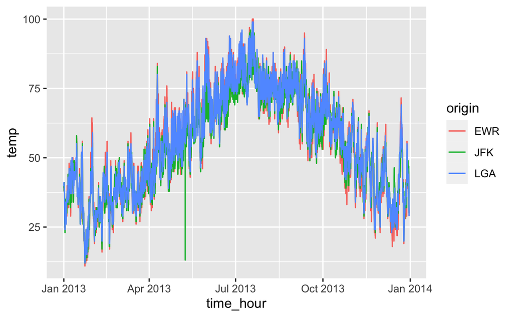

```r
nyc_weather %>%
  ggplot() +
  geom_line(aes(x = time_hour, y = temp, colour = origin))
```

Have a think back to what you learned in visualisation week, and think about whether plotting the whole time series in one go is adequate here?

##No. shows hour by hour variation where daily or monthly would be sufficient.

Write down your suggestions for what could be done to make a better and more informative plot.

##select data over a more finite time series, ie over days or months as opposed to over hours.

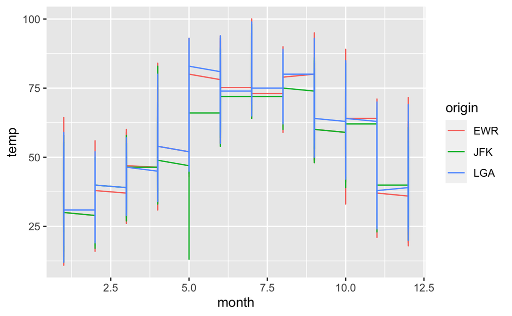

```r
nyc_weather %>%
  ggplot() +
  geom_line(aes(x = month, y = temp, colour = origin))
```

**Question 9**

Choose an appropriate rolling window and calculate a moving average for your weather temperature data for each airport origin.

```r
library(slider)

weather_rolling <- nyc_weather %>%
  mutate(temp_moving_avg = slide_dbl(
    .x = temp,
    .f = ~ mean(., na.rm = TRUE),
    .before = 1000,
    .after = 1000

  )
)

weather_rolling
```

| origin | temp | humid | precip | time_hour | year | month | temp_moving_avg |
| --- | --- | --- | --- | --- | --- | --- | --- |
| EWR | 39.02 | 59.37 | 0.00 | 2013-01-01 01:00:00 | 2013 | 1 | 34.02118 |
| EWR | 39.02 | 61.63 | 0.00 | 2013-01-01 02:00:00 | 2013 | 1 | 34.03012 |
| EWR | 39.02 | 64.43 | 0.00 | 2013-01-01 03:00:00 | 2013 | 1 | 34.03815 |
| EWR | 39.92 | 62.21 | 0.00 | 2013-01-01 04:00:00 | 2013 | 1 | 34.04705 |
| EWR | 39.02 | 64.43 | 0.00 | 2013-01-01 05:00:00 | 2013 | 1 | 34.05701 |
| EWR | 37.94 | 67.21 | 0.00 | 2013-01-01 06:00:00 | 2013 | 1 | 34.06750 |
| EWR | 39.02 | 64.43 | 0.00 | 2013-01-01 07:00:00 | 2013 | 1 | 34.07331 |
| EWR | 39.92 | 62.21 | 0.00 | 2013-01-01 08:00:00 | 2013 | 1 | 34.07911 |
| EWR | 39.92 | 62.21 | 0.00 | 2013-01-01 09:00:00 | 2013 | 1 | 34.08490 |
| EWR | 41.00 | 59.65 | 0.00 | 2013-01-01 10:00:00 | 2013 | 1 | 34.08978 |

[output cut: 990 more lines]

```r
ggplot(weather_rolling) +
  geom_line(aes(x = time_hour, y = temp), colour = "grey") +
  geom_line(aes(x = time_hour, y = temp_moving_avg), colour = "red")+
   facet_wrap(~ origin) +
  ylab("temp") +
  xlab("time_hour")
```

[output not shown]

Create a useful plot which overlays the original time series data and the rolling average data. Make sure the graph is easy for others to understand (*Hint: you might want to facet_wrap*).

Do a facet_wrap() to illustrate rollng_temp_avg at each origin.

Chose time_hour as it was more sensitive than month though day might have been interesting to see.

**Question 10**

Downsample your data so that you plot daily temperature data for each airport, instead of hourly data.